# Risk Factor Analysis

## Outcome Variable

**Outcome Variable:** wast_rec90d

## Predictor Variables

**Intervention Variable:** gagebrth

**Adjustment Set:**

- arm
- sex
- W_mage
- meducyrs
- feducyrs
- hhwealth_quart
- W_nrooms
- W_nchldlt5
- brthmon
- W_parity
- impfloor
- impsan
- safeh20
- delta_W_mage
- delta_meducyrs
- delta_feducyrs
- delta_hhwealth_quart
- delta_W_nrooms
- delta_W_nchldlt5
- delta_brthmon
- delta_W_parity
- delta_impfloor
- delta_impsan
- delta_safeh20

## Stratifying Variables

The analysis was stratified on these variable(s):

- agecat
- studyid
- country

## Data Summary

| agecat | studyid | country | gagebrth | wast_rec90d | n_cell | n |
| --- | --- | --- | --- | --- | --- | --- |
| 0-24 months | ki1000108-CMC-V-BCS-2002 | INDIA | Full or late term | 0 | 68 | 301 |
| 0-24 months | ki1000108-CMC-V-BCS-2002 | INDIA | Full or late term | 1 | 119 | 301 |
| 0-24 months | ki1000108-CMC-V-BCS-2002 | INDIA | Preterm | 0 | 21 | 301 |
| 0-24 months | ki1000108-CMC-V-BCS-2002 | INDIA | Preterm | 1 | 28 | 301 |
| 0-24 months | ki1000108-CMC-V-BCS-2002 | INDIA | Early term | 0 | 21 | 301 |
| 0-24 months | ki1000108-CMC-V-BCS-2002 | INDIA | Early term | 1 | 44 | 301 |
| 0-24 months | ki1000108-IRC | INDIA | Full or late term | 0 | 92 | 382 |
| 0-24 months | ki1000108-IRC | INDIA | Full or late term | 1 | 134 | 382 |
| 0-24 months | ki1000108-IRC | INDIA | Preterm | 0 | 24 | 382 |
| 0-24 months | ki1000108-IRC | INDIA | Preterm | 1 | 29 | 382 |
| 0-24 months | ki1000108-IRC | INDIA | Early term | 0 | 39 | 382 |
| 0-24 months | ki1000108-IRC | INDIA | Early term | 1 | 64 | 382 |
| 0-24 months | ki1000109-EE | PAKISTAN | Full or late term | 0 | 8 | 514 |
| 0-24 months | ki1000109-EE | PAKISTAN | Full or late term | 1 | 12 | 514 |
| 0-24 months | ki1000109-EE | PAKISTAN | Preterm | 0 | 196 | 514 |
| 0-24 months | ki1000109-EE | PAKISTAN | Preterm | 1 | 156 | 514 |
| 0-24 months | ki1000109-EE | PAKISTAN | Early term | 0 | 96 | 514 |
| 0-24 months | ki1000109-EE | PAKISTAN | Early term | 1 | 46 | 514 |
| 0-24 months | ki1000304b-SAS-CompFeed | INDIA | Full or late term | 0 | 9 | 810 |
| 0-24 months | ki1000304b-SAS-CompFeed | INDIA | Full or late term | 1 | 5 | 810 |
| 0-24 months | ki1000304b-SAS-CompFeed | INDIA | Preterm | 0 | 463 | 810 |
| 0-24 months | ki1000304b-SAS-CompFeed | INDIA | Preterm | 1 | 282 | 810 |
| 0-24 months | ki1000304b-SAS-CompFeed | INDIA | Early term | 0 | 29 | 810 |
| 0-24 months | ki1000304b-SAS-CompFeed | INDIA | Early term | 1 | 22 | 810 |
| 0-24 months | ki1017093c-NIH-Crypto | BANGLADESH | Full or late term | 0 | 16 | 311 |
| 0-24 months | ki1017093c-NIH-Crypto | BANGLADESH | Full or late term | 1 | 26 | 311 |
| 0-24 months | ki1017093c-NIH-Crypto | BANGLADESH | Preterm | 0 | 57 | 311 |
| 0-24 months | ki1017093c-NIH-Crypto | BANGLADESH | Preterm | 1 | 92 | 311 |
| 0-24 months | ki1017093c-NIH-Crypto | BANGLADESH | Early term | 0 | 44 | 311 |
| 0-24 months | ki1017093c-NIH-Crypto | BANGLADESH | Early term | 1 | 76 | 311 |

[output cut: 186 more lines]

The following strata were considered:

- agecat: 0-24 months, studyid: ki1000108-CMC-V-BCS-2002, country: INDIA
- agecat: 0-24 months, studyid: ki1000108-IRC, country: INDIA
- agecat: 0-24 months, studyid: ki1000109-EE, country: PAKISTAN
- agecat: 0-24 months, studyid: ki1000304b-SAS-CompFeed, country: INDIA
- agecat: 0-24 months, studyid: ki1017093c-NIH-Crypto, country: BANGLADESH
- agecat: 0-24 months, studyid: ki1066203-TanzaniaChild2, country: TANZANIA, UNITED REPUBLIC OF
- agecat: 0-24 months, studyid: ki1101329-Keneba, country: GAMBIA
- agecat: 0-24 months, studyid: ki1119695-PROBIT, country: BELARUS
- agecat: 0-24 months, studyid: ki1135781-COHORTS, country: GUATEMALA
- agecat: 0-24 months, studyid: ki1135781-COHORTS, country: INDIA
- agecat: 0-24 months, studyid: ki1135781-COHORTS, country: PHILIPPINES
- agecat: 0-24 months, studyid: kiGH5241-JiVitA-3, country: BANGLADESH
- agecat: 0-6 months, studyid: ki1000108-CMC-V-BCS-2002, country: INDIA
- agecat: 0-6 months, studyid: ki1000108-IRC, country: INDIA
- agecat: 0-6 months, studyid: ki1000109-EE, country: PAKISTAN
- agecat: 0-6 months, studyid: ki1000304b-SAS-CompFeed, country: INDIA
- agecat: 0-6 months, studyid: ki1017093c-NIH-Crypto, country: BANGLADESH
- agecat: 0-6 months, studyid: ki1066203-TanzaniaChild2, country: TANZANIA, UNITED REPUBLIC OF
- agecat: 0-6 months, studyid: ki1101329-Keneba, country: GAMBIA
- agecat: 0-6 months, studyid: ki1119695-PROBIT, country: BELARUS
- agecat: 0-6 months, studyid: ki1135781-COHORTS, country: GUATEMALA
- agecat: 0-6 months, studyid: ki1135781-COHORTS, country: INDIA
- agecat: 0-6 months, studyid: ki1135781-COHORTS, country: PHILIPPINES
- agecat: 0-6 months, studyid: kiGH5241-JiVitA-3, country: BANGLADESH
- agecat: 6-24 months, studyid: ki1000108-CMC-V-BCS-2002, country: INDIA
- agecat: 6-24 months, studyid: ki1000108-IRC, country: INDIA
- agecat: 6-24 months, studyid: ki1000109-EE, country: PAKISTAN
- agecat: 6-24 months, studyid: ki1000304b-SAS-CompFeed, country: INDIA
- agecat: 6-24 months, studyid: ki1017093c-NIH-Crypto, country: BANGLADESH
- agecat: 6-24 months, studyid: ki1066203-TanzaniaChild2, country: TANZANIA, UNITED REPUBLIC OF
- agecat: 6-24 months, studyid: ki1101329-Keneba, country: GAMBIA
- agecat: 6-24 months, studyid: ki1119695-PROBIT, country: BELARUS
- agecat: 6-24 months, studyid: ki1135781-COHORTS, country: GUATEMALA
- agecat: 6-24 months, studyid: ki1135781-COHORTS, country: INDIA
- agecat: 6-24 months, studyid: ki1135781-COHORTS, country: PHILIPPINES
- agecat: 6-24 months, studyid: kiGH5241-JiVitA-3, country: BANGLADESH

### Dropped Strata

Some strata were dropped due to rare outcomes:

- agecat: 0-6 months, studyid: ki1000109-EE, country: PAKISTAN
- agecat: 0-6 months, studyid: ki1000304b-SAS-CompFeed, country: INDIA
- agecat: 0-6 months, studyid: ki1017093c-NIH-Crypto, country: BANGLADESH
- agecat: 6-24 months, studyid: ki1000109-EE, country: PAKISTAN
- agecat: 6-24 months, studyid: ki1000304b-SAS-CompFeed, country: INDIA
- agecat: 6-24 months, studyid: ki1017093c-NIH-Crypto, country: BANGLADESH
- agecat: 6-24 months, studyid: ki1119695-PROBIT, country: BELARUS
- agecat: 6-24 months, studyid: ki1135781-COHORTS, country: GUATEMALA
- agecat: 6-24 months, studyid: ki1135781-COHORTS, country: INDIA
- agecat: 6-24 months, studyid: kiGH5241-JiVitA-3, country: BANGLADESH

## Methods Detail

We’re interested in the causal parameters $E[Y_a]$ for all values of $a \in \mathcal{A}$. These parameters represent the mean outcome if, possibly contrary to fact, we intervened to set all units to have $A=a$. Under the randomization and positivity assumptions, these are identified by the statistical parameters $\psi_a=E_W[E_{Y|A,W}(Y|A=a,W)]$. In addition, we’re interested in the mean of $Y$, $E[Y]$ under no intervention (the observed mean). We will estimate these parameters by using SuperLearner to fit the relevant likelihood factors – $E_{Y|A,W}(Y|A=a,W)$ and $p(A=a|W)$, and then updating our likelihood fit using a joint TMLE.

For unadjusted analyses ($W=\{\}$), initial likelihoods were estimated using Lrnr_glm to estimate the simple $E(Y|A)$ and Lrnr_mean to estimate $p(A)$. For adjusted analyses, a small library containing Lrnr_glmnet, Lrnr_xgboost, and Lrnr_mean was used.

Having estimated these parameters, we will then use the delta method to estimate relative risks and attributable risks relative to a prespecified baseline level of $A$.

# Results Detail

## Results Plots

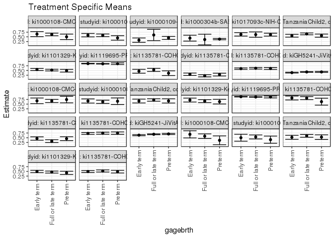

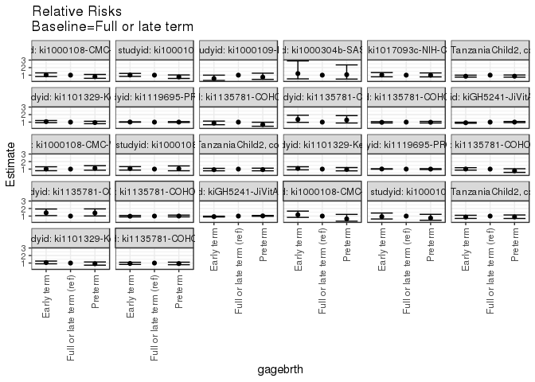

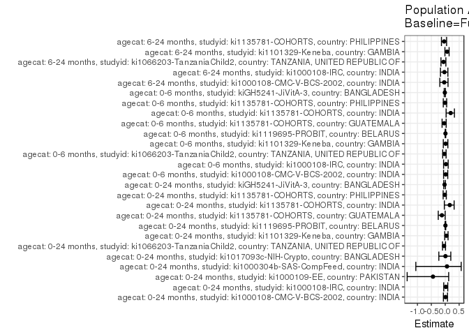

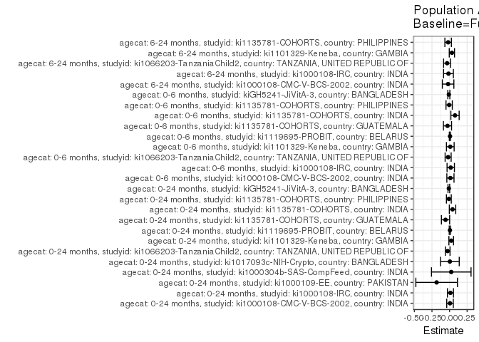

## Results Table

### Parameter: TSM

| agecat | studyid | country | intervention_level | baseline_level | estimate | ci_lower | ci_upper |
| --- | --- | --- | --- | --- | --- | --- | --- |
| 0-24 months | ki1000108-CMC-V-BCS-2002 | INDIA | Full or late term | NA | 0.6280387 | 0.5586597 | 0.6974177 |
| 0-24 months | ki1000108-CMC-V-BCS-2002 | INDIA | Preterm | NA | 0.5013908 | 0.3539088 | 0.6488728 |
| 0-24 months | ki1000108-CMC-V-BCS-2002 | INDIA | Early term | NA | 0.6447755 | 0.5099363 | 0.7796147 |
| 0-24 months | ki1000108-IRC | INDIA | Full or late term | NA | 0.5816792 | 0.5104851 | 0.6528733 |
| 0-24 months | ki1000108-IRC | INDIA | Preterm | NA | 0.4425081 | 0.3226680 | 0.5623482 |
| 0-24 months | ki1000108-IRC | INDIA | Early term | NA | 0.5884173 | 0.4977831 | 0.6790516 |
| 0-24 months | ki1000109-EE | PAKISTAN | Full or late term | NA | 0.6000000 | 0.3000972 | 0.8999028 |
| 0-24 months | ki1000109-EE | PAKISTAN | Preterm | NA | 0.4431818 | 0.3628195 | 0.5235442 |
| 0-24 months | ki1000109-EE | PAKISTAN | Early term | NA | 0.3239437 | 0.2074617 | 0.4404256 |
| 0-24 months | ki1000304b-SAS-CompFeed | INDIA | Full or late term | NA | 0.3571429 | 0.0731496 | 0.6411361 |
| 0-24 months | ki1000304b-SAS-CompFeed | INDIA | Preterm | NA | 0.3785235 | 0.3421693 | 0.4148777 |
| 0-24 months | ki1000304b-SAS-CompFeed | INDIA | Early term | NA | 0.4313725 | 0.2762267 | 0.5865184 |
| 0-24 months | ki1017093c-NIH-Crypto | BANGLADESH | Full or late term | NA | 0.6190476 | 0.4768572 | 0.7612380 |
| 0-24 months | ki1017093c-NIH-Crypto | BANGLADESH | Preterm | NA | 0.6174497 | 0.5406725 | 0.6942268 |
| 0-24 months | ki1017093c-NIH-Crypto | BANGLADESH | Early term | NA | 0.6333333 | 0.5434169 | 0.7232498 |
| 0-24 months | ki1066203-TanzaniaChild2 | TANZANIA, UNITED REPUBLIC OF | Full or late term | NA | 0.6559149 | 0.6060237 | 0.7058060 |
| 0-24 months | ki1066203-TanzaniaChild2 | TANZANIA, UNITED REPUBLIC OF | Preterm | NA | 0.5647100 | 0.4800449 | 0.6493752 |
| 0-24 months | ki1066203-TanzaniaChild2 | TANZANIA, UNITED REPUBLIC OF | Early term | NA | 0.5599608 | 0.4847581 | 0.6351635 |
| 0-24 months | ki1101329-Keneba | GAMBIA | Full or late term | NA | 0.5201852 | 0.4742012 | 0.5661693 |
| 0-24 months | ki1101329-Keneba | GAMBIA | Preterm | NA | 0.4879611 | 0.4151656 | 0.5607565 |
| 0-24 months | ki1101329-Keneba | GAMBIA | Early term | NA | 0.5519825 | 0.4948851 | 0.6090799 |
| 0-24 months | ki1119695-PROBIT | BELARUS | Full or late term | NA | 0.8554657 | 0.8407713 | 0.8701600 |
| 0-24 months | ki1119695-PROBIT | BELARUS | Preterm | NA | 0.8612670 | 0.8174947 | 0.9050393 |
| 0-24 months | ki1119695-PROBIT | BELARUS | Early term | NA | 0.8660294 | 0.8516002 | 0.8804587 |
| 0-24 months | ki1135781-COHORTS | GUATEMALA | Full or late term | NA | 0.5321110 | 0.4481462 | 0.6160759 |
| 0-24 months | ki1135781-COHORTS | GUATEMALA | Preterm | NA | 0.3548489 | 0.2286996 | 0.4809982 |
| 0-24 months | ki1135781-COHORTS | GUATEMALA | Early term | NA | 0.4602042 | 0.3562257 | 0.5641828 |
| 0-24 months | ki1135781-COHORTS | INDIA | Full or late term | NA | 0.2195650 | 0.1610002 | 0.2781297 |
| 0-24 months | ki1135781-COHORTS | INDIA | Preterm | NA | 0.2811334 | 0.2062370 | 0.3560297 |
| 0-24 months | ki1135781-COHORTS | INDIA | Early term | NA | 0.2984451 | 0.2343123 | 0.3625779 |
| 0-24 months | ki1135781-COHORTS | PHILIPPINES | Full or late term | NA | 0.6160109 | 0.5731297 | 0.6588920 |
| 0-24 months | ki1135781-COHORTS | PHILIPPINES | Preterm | NA | 0.6049892 | 0.5550780 | 0.6549004 |
| 0-24 months | ki1135781-COHORTS | PHILIPPINES | Early term | NA | 0.5984413 | 0.5609620 | 0.6359206 |
| 0-24 months | kiGH5241-JiVitA-3 | BANGLADESH | Full or late term | NA | 0.4210477 | 0.4033997 | 0.4386956 |
| 0-24 months | kiGH5241-JiVitA-3 | BANGLADESH | Preterm | NA | 0.4222308 | 0.3954760 | 0.4489856 |
| 0-24 months | kiGH5241-JiVitA-3 | BANGLADESH | Early term | NA | 0.3853764 | 0.3618557 | 0.4088972 |
| 0-6 months | ki1000108-CMC-V-BCS-2002 | INDIA | Full or late term | NA | 0.6666667 | 0.5821538 | 0.7511795 |
| 0-6 months | ki1000108-CMC-V-BCS-2002 | INDIA | Preterm | NA | 0.7407407 | 0.5657628 | 0.9157187 |
| 0-6 months | ki1000108-CMC-V-BCS-2002 | INDIA | Early term | NA | 0.6750000 | 0.5250907 | 0.8249093 |
| 0-6 months | ki1000108-IRC | INDIA | Full or late term | NA | 0.6222222 | 0.5361698 | 0.7082747 |
| 0-6 months | ki1000108-IRC | INDIA | Preterm | NA | 0.6538462 | 0.4797295 | 0.8279628 |
| 0-6 months | ki1000108-IRC | INDIA | Early term | NA | 0.6666667 | 0.5568093 | 0.7765240 |
| 0-6 months | ki1066203-TanzaniaChild2 | TANZANIA, UNITED REPUBLIC OF | Full or late term | NA | 0.7194362 | 0.6545136 | 0.7843588 |
| 0-6 months | ki1066203-TanzaniaChild2 | TANZANIA, UNITED REPUBLIC OF | Preterm | NA | 0.6696799 | 0.5581747 | 0.7811852 |
| 0-6 months | ki1066203-TanzaniaChild2 | TANZANIA, UNITED REPUBLIC OF | Early term | NA | 0.6643069 | 0.5616012 | 0.7670126 |
| 0-6 months | ki1101329-Keneba | GAMBIA | Full or late term | NA | 0.6587505 | 0.5788133 | 0.7386878 |
| 0-6 months | ki1101329-Keneba | GAMBIA | Preterm | NA | 0.6317600 | 0.5082845 | 0.7552354 |
| 0-6 months | ki1101329-Keneba | GAMBIA | Early term | NA | 0.7159351 | 0.6122256 | 0.8196446 |
| 0-6 months | ki1119695-PROBIT | BELARUS | Full or late term | NA | 0.8788104 | 0.8647972 | 0.8928237 |
| 0-6 months | ki1119695-PROBIT | BELARUS | Preterm | NA | 0.8796380 | 0.8291252 | 0.9301508 |
| 0-6 months | ki1119695-PROBIT | BELARUS | Early term | NA | 0.8931132 | 0.8794327 | 0.9067937 |
| 0-6 months | ki1135781-COHORTS | GUATEMALA | Full or late term | NA | 0.8181818 | 0.7368393 | 0.8995243 |
| 0-6 months | ki1135781-COHORTS | GUATEMALA | Preterm | NA | 0.6296296 | 0.4457667 | 0.8134926 |
| 0-6 months | ki1135781-COHORTS | GUATEMALA | Early term | NA | 0.8260870 | 0.7207224 | 0.9314515 |
| 0-6 months | ki1135781-COHORTS | INDIA | Full or late term | NA | 0.3204981 | 0.2454878 | 0.3955083 |
| 0-6 months | ki1135781-COHORTS | INDIA | Preterm | NA | 0.4513494 | 0.3470343 | 0.5556646 |
| 0-6 months | ki1135781-COHORTS | INDIA | Early term | NA | 0.4601570 | 0.3711645 | 0.5491495 |
| 0-6 months | ki1135781-COHORTS | PHILIPPINES | Full or late term | NA | 0.7423179 | 0.6878413 | 0.7967945 |
| 0-6 months | ki1135781-COHORTS | PHILIPPINES | Preterm | NA | 0.7453188 | 0.6811300 | 0.8095075 |
| 0-6 months | ki1135781-COHORTS | PHILIPPINES | Early term | NA | 0.7271849 | 0.6783169 | 0.7760528 |
| 0-6 months | kiGH5241-JiVitA-3 | BANGLADESH | Full or late term | NA | 0.6844093 | 0.6633895 | 0.7054290 |
| 0-6 months | kiGH5241-JiVitA-3 | BANGLADESH | Preterm | NA | 0.7017722 | 0.6706743 | 0.7328701 |
| 0-6 months | kiGH5241-JiVitA-3 | BANGLADESH | Early term | NA | 0.6368666 | 0.6074190 | 0.6663142 |
| 6-24 months | ki1000108-CMC-V-BCS-2002 | INDIA | Full or late term | NA | 0.5820896 | 0.4594727 | 0.7047064 |
| 6-24 months | ki1000108-CMC-V-BCS-2002 | INDIA | Preterm | NA | 0.3636364 | 0.1308138 | 0.5964590 |
| 6-24 months | ki1000108-CMC-V-BCS-2002 | INDIA | Early term | NA | 0.6800000 | 0.4890151 | 0.8709849 |
| 6-24 months | ki1000108-IRC | INDIA | Full or late term | NA | 0.5418355 | 0.4353121 | 0.6483589 |
| 6-24 months | ki1000108-IRC | INDIA | Preterm | NA | 0.3966983 | 0.2055648 | 0.5878318 |
| 6-24 months | ki1000108-IRC | INDIA | Early term | NA | 0.5015551 | 0.3181253 | 0.6849849 |
| 6-24 months | ki1066203-TanzaniaChild2 | TANZANIA, UNITED REPUBLIC OF | Full or late term | NA | 0.6005186 | 0.5291140 | 0.6719231 |
| 6-24 months | ki1066203-TanzaniaChild2 | TANZANIA, UNITED REPUBLIC OF | Preterm | NA | 0.5322252 | 0.4087411 | 0.6557094 |
| 6-24 months | ki1066203-TanzaniaChild2 | TANZANIA, UNITED REPUBLIC OF | Early term | NA | 0.5239174 | 0.4170650 | 0.6307698 |
| 6-24 months | ki1101329-Keneba | GAMBIA | Full or late term | NA | 0.4639046 | 0.4103633 | 0.5174458 |
| 6-24 months | ki1101329-Keneba | GAMBIA | Preterm | NA | 0.4210933 | 0.3349218 | 0.5072648 |
| 6-24 months | ki1101329-Keneba | GAMBIA | Early term | NA | 0.4939094 | 0.4310523 | 0.5567666 |
| 6-24 months | ki1135781-COHORTS | PHILIPPINES | Full or late term | NA | 0.5214724 | 0.4634910 | 0.5794538 |
| 6-24 months | ki1135781-COHORTS | PHILIPPINES | Preterm | NA | 0.4859813 | 0.4159761 | 0.5559865 |
| 6-24 months | ki1135781-COHORTS | PHILIPPINES | Early term | NA | 0.4936061 | 0.4414105 | 0.5458018 |

### Parameter: E(Y)

| agecat | studyid | country | intervention_level | baseline_level | estimate | ci_lower | ci_upper |
| --- | --- | --- | --- | --- | --- | --- | --- |
| 0-24 months | ki1000108-CMC-V-BCS-2002 | INDIA | NA | NA | 0.6345515 | 0.5770351 | 0.6920679 |
| 0-24 months | ki1000108-IRC | INDIA | NA | NA | 0.5942408 | 0.5412823 | 0.6471994 |
| 0-24 months | ki1000109-EE | PAKISTAN | NA | NA | 0.4163424 | 0.3511349 | 0.4815500 |
| 0-24 months | ki1000304b-SAS-CompFeed | INDIA | NA | NA | 0.3814815 | 0.3462984 | 0.4166645 |
| 0-24 months | ki1017093c-NIH-Crypto | BANGLADESH | NA | NA | 0.6237942 | 0.5698223 | 0.6777662 |
| 0-24 months | ki1066203-TanzaniaChild2 | TANZANIA, UNITED REPUBLIC OF | NA | NA | 0.6291291 | 0.5901846 | 0.6680736 |
| 0-24 months | ki1101329-Keneba | GAMBIA | NA | NA | 0.5435467 | 0.5088559 | 0.5782375 |
| 0-24 months | ki1119695-PROBIT | BELARUS | NA | NA | 0.8612051 | 0.8511051 | 0.8713052 |
| 0-24 months | ki1135781-COHORTS | GUATEMALA | NA | NA | 0.4750000 | 0.4147665 | 0.5352335 |
| 0-24 months | ki1135781-COHORTS | INDIA | NA | NA | 0.2619503 | 0.2237649 | 0.3001357 |
| 0-24 months | ki1135781-COHORTS | PHILIPPINES | NA | NA | 0.6059701 | 0.5813402 | 0.6306001 |
| 0-24 months | kiGH5241-JiVitA-3 | BANGLADESH | NA | NA | 0.4112116 | 0.3983175 | 0.4241057 |
| 0-6 months | ki1000108-CMC-V-BCS-2002 | INDIA | NA | NA | 0.6791444 | 0.6111760 | 0.7471128 |
| 0-6 months | ki1000108-IRC | INDIA | NA | NA | 0.6391304 | 0.5756367 | 0.7026242 |
| 0-6 months | ki1066203-TanzaniaChild2 | TANZANIA, UNITED REPUBLIC OF | NA | NA | 0.6993671 | 0.6481378 | 0.7505964 |
| 0-6 months | ki1101329-Keneba | GAMBIA | NA | NA | 0.6692607 | 0.6118880 | 0.7266334 |
| 0-6 months | ki1119695-PROBIT | BELARUS | NA | NA | 0.8855266 | 0.8758983 | 0.8951550 |
| 0-6 months | ki1135781-COHORTS | GUATEMALA | NA | NA | 0.7888199 | 0.7258783 | 0.8517615 |
| 0-6 months | ki1135781-COHORTS | INDIA | NA | NA | 0.3982558 | 0.3464489 | 0.4500628 |
| 0-6 months | ki1135781-COHORTS | PHILIPPINES | NA | NA | 0.7365591 | 0.7047881 | 0.7683302 |
| 0-6 months | kiGH5241-JiVitA-3 | BANGLADESH | NA | NA | 0.6746988 | 0.6589571 | 0.6904405 |
| 6-24 months | ki1000108-CMC-V-BCS-2002 | INDIA | NA | NA | 0.5614035 | 0.4645960 | 0.6582110 |
| 6-24 months | ki1000108-IRC | INDIA | NA | NA | 0.5263158 | 0.4415211 | 0.6111105 |
| 6-24 months | ki1066203-TanzaniaChild2 | TANZANIA, UNITED REPUBLIC OF | NA | NA | 0.5657143 | 0.5118874 | 0.6195411 |
| 6-24 months | ki1101329-Keneba | GAMBIA | NA | NA | 0.4971264 | 0.4573928 | 0.5368601 |
| 6-24 months | ki1135781-COHORTS | PHILIPPINES | NA | NA | 0.5016112 | 0.4676556 | 0.5355667 |

### Parameter: RR

| agecat | studyid | country | intervention_level | baseline_level | estimate | ci_lower | ci_upper |
| --- | --- | --- | --- | --- | --- | --- | --- |
| 0-24 months | ki1000108-CMC-V-BCS-2002 | INDIA | Full or late term | Full or late term | 1.0000000 | 1.0000000 | 1.0000000 |
| 0-24 months | ki1000108-CMC-V-BCS-2002 | INDIA | Preterm | Full or late term | 0.7983438 | 0.5824317 | 1.0942962 |
| 0-24 months | ki1000108-CMC-V-BCS-2002 | INDIA | Early term | Full or late term | 1.0266493 | 0.8102066 | 1.3009136 |
| 0-24 months | ki1000108-IRC | INDIA | Full or late term | Full or late term | 1.0000000 | 1.0000000 | 1.0000000 |
| 0-24 months | ki1000108-IRC | INDIA | Preterm | Full or late term | 0.7607425 | 0.5646630 | 1.0249107 |
| 0-24 months | ki1000108-IRC | INDIA | Early term | Full or late term | 1.0115839 | 0.8304882 | 1.2321692 |
| 0-24 months | ki1000109-EE | PAKISTAN | Full or late term | Full or late term | 1.0000000 | 1.0000000 | 1.0000000 |
| 0-24 months | ki1000109-EE | PAKISTAN | Preterm | Full or late term | 0.7386364 | 0.4339694 | 1.2571940 |
| 0-24 months | ki1000109-EE | PAKISTAN | Early term | Full or late term | 0.5399061 | 0.2916843 | 0.9993635 |
| 0-24 months | ki1000304b-SAS-CompFeed | INDIA | Full or late term | Full or late term | 1.0000000 | 1.0000000 | 1.0000000 |
| 0-24 months | ki1000304b-SAS-CompFeed | INDIA | Preterm | Full or late term | 1.0598658 | 0.4757869 | 2.3609635 |
| 0-24 months | ki1000304b-SAS-CompFeed | INDIA | Early term | Full or late term | 1.2078431 | 0.5046764 | 2.8907336 |
| 0-24 months | ki1017093c-NIH-Crypto | BANGLADESH | Full or late term | Full or late term | 1.0000000 | 1.0000000 | 1.0000000 |
| 0-24 months | ki1017093c-NIH-Crypto | BANGLADESH | Preterm | Full or late term | 0.9974187 | 0.7680002 | 1.2953695 |
| 0-24 months | ki1017093c-NIH-Crypto | BANGLADESH | Early term | Full or late term | 1.0230769 | 0.7807062 | 1.3406918 |
| 0-24 months | ki1066203-TanzaniaChild2 | TANZANIA, UNITED REPUBLIC OF | Full or late term | Full or late term | 1.0000000 | 1.0000000 | 1.0000000 |
| 0-24 months | ki1066203-TanzaniaChild2 | TANZANIA, UNITED REPUBLIC OF | Preterm | Full or late term | 0.8609502 | 0.7280246 | 1.0181458 |
| 0-24 months | ki1066203-TanzaniaChild2 | TANZANIA, UNITED REPUBLIC OF | Early term | Full or late term | 0.8537096 | 0.7320129 | 0.9956382 |
| 0-24 months | ki1101329-Keneba | GAMBIA | Full or late term | Full or late term | 1.0000000 | 1.0000000 | 1.0000000 |
| 0-24 months | ki1101329-Keneba | GAMBIA | Preterm | Full or late term | 0.9380525 | 0.7895508 | 1.1144850 |
| 0-24 months | ki1101329-Keneba | GAMBIA | Early term | Full or late term | 1.0611268 | 0.9269287 | 1.2147538 |
| 0-24 months | ki1119695-PROBIT | BELARUS | Full or late term | Full or late term | 1.0000000 | 1.0000000 | 1.0000000 |
| 0-24 months | ki1119695-PROBIT | BELARUS | Preterm | Full or late term | 1.0067815 | 0.9541952 | 1.0622658 |
| 0-24 months | ki1119695-PROBIT | BELARUS | Early term | Full or late term | 1.0123485 | 0.9884110 | 1.0368658 |
| 0-24 months | ki1135781-COHORTS | GUATEMALA | Full or late term | Full or late term | 1.0000000 | 1.0000000 | 1.0000000 |
| 0-24 months | ki1135781-COHORTS | GUATEMALA | Preterm | Full or late term | 0.6668701 | 0.4519129 | 0.9840741 |
| 0-24 months | ki1135781-COHORTS | GUATEMALA | Early term | Full or late term | 0.8648651 | 0.6578929 | 1.1369505 |
| 0-24 months | ki1135781-COHORTS | INDIA | Full or late term | Full or late term | 1.0000000 | 1.0000000 | 1.0000000 |
| 0-24 months | ki1135781-COHORTS | INDIA | Preterm | Full or late term | 1.2804108 | 0.8795126 | 1.8640459 |
| 0-24 months | ki1135781-COHORTS | INDIA | Early term | Full or late term | 1.3592567 | 0.9680766 | 1.9085048 |
| 0-24 months | ki1135781-COHORTS | PHILIPPINES | Full or late term | Full or late term | 1.0000000 | 1.0000000 | 1.0000000 |
| 0-24 months | ki1135781-COHORTS | PHILIPPINES | Preterm | Full or late term | 0.9821080 | 0.8816963 | 1.0939550 |
| 0-24 months | ki1135781-COHORTS | PHILIPPINES | Early term | Full or late term | 0.9714785 | 0.8847780 | 1.0666748 |
| 0-24 months | kiGH5241-JiVitA-3 | BANGLADESH | Full or late term | Full or late term | 1.0000000 | 1.0000000 | 1.0000000 |
| 0-24 months | kiGH5241-JiVitA-3 | BANGLADESH | Preterm | Full or late term | 1.0028100 | 0.9296989 | 1.0816704 |
| 0-24 months | kiGH5241-JiVitA-3 | BANGLADESH | Early term | Full or late term | 0.9152799 | 0.8501807 | 0.9853638 |
| 0-6 months | ki1000108-CMC-V-BCS-2002 | INDIA | Full or late term | Full or late term | 1.0000000 | 1.0000000 | 1.0000000 |
| 0-6 months | ki1000108-CMC-V-BCS-2002 | INDIA | Preterm | Full or late term | 1.1111111 | 0.8498176 | 1.4527446 |
| 0-6 months | ki1000108-CMC-V-BCS-2002 | INDIA | Early term | Full or late term | 1.0125000 | 0.7840402 | 1.3075303 |
| 0-6 months | ki1000108-IRC | INDIA | Full or late term | Full or late term | 1.0000000 | 1.0000000 | 1.0000000 |
| 0-6 months | ki1000108-IRC | INDIA | Preterm | Full or late term | 1.0508242 | 0.7784047 | 1.4185827 |
| 0-6 months | ki1000108-IRC | INDIA | Early term | Full or late term | 1.0714286 | 0.8640328 | 1.3286061 |
| 0-6 months | ki1066203-TanzaniaChild2 | TANZANIA, UNITED REPUBLIC OF | Full or late term | Full or late term | 1.0000000 | 1.0000000 | 1.0000000 |
| 0-6 months | ki1066203-TanzaniaChild2 | TANZANIA, UNITED REPUBLIC OF | Preterm | Full or late term | 0.9308399 | 0.7705393 | 1.1244891 |
| 0-6 months | ki1066203-TanzaniaChild2 | TANZANIA, UNITED REPUBLIC OF | Early term | Full or late term | 0.9233715 | 0.7725964 | 1.1035711 |
| 0-6 months | ki1101329-Keneba | GAMBIA | Full or late term | Full or late term | 1.0000000 | 1.0000000 | 1.0000000 |
| 0-6 months | ki1101329-Keneba | GAMBIA | Preterm | Full or late term | 0.9590276 | 0.7631580 | 1.2051685 |
| 0-6 months | ki1101329-Keneba | GAMBIA | Early term | Full or late term | 1.0868076 | 0.9003884 | 1.3118236 |
| 0-6 months | ki1119695-PROBIT | BELARUS | Full or late term | Full or late term | 1.0000000 | 1.0000000 | 1.0000000 |
| 0-6 months | ki1119695-PROBIT | BELARUS | Preterm | Full or late term | 1.0009416 | 0.9430339 | 1.0624052 |
| 0-6 months | ki1119695-PROBIT | BELARUS | Early term | Full or late term | 1.0162751 | 0.9940546 | 1.0389923 |
| 0-6 months | ki1135781-COHORTS | GUATEMALA | Full or late term | Full or late term | 1.0000000 | 1.0000000 | 1.0000000 |
| 0-6 months | ki1135781-COHORTS | GUATEMALA | Preterm | Full or late term | 0.7695473 | 0.5652821 | 1.0476239 |
| 0-6 months | ki1135781-COHORTS | GUATEMALA | Early term | Full or late term | 1.0096618 | 0.8589016 | 1.1868846 |
| 0-6 months | ki1135781-COHORTS | INDIA | Full or late term | Full or late term | 1.0000000 | 1.0000000 | 1.0000000 |
| 0-6 months | ki1135781-COHORTS | INDIA | Preterm | Full or late term | 1.4082750 | 1.0150221 | 1.9538871 |
| 0-6 months | ki1135781-COHORTS | INDIA | Early term | Full or late term | 1.4357559 | 1.0621421 | 1.9407903 |
| 0-6 months | ki1135781-COHORTS | PHILIPPINES | Full or late term | Full or late term | 1.0000000 | 1.0000000 | 1.0000000 |
| 0-6 months | ki1135781-COHORTS | PHILIPPINES | Preterm | Full or late term | 1.0040425 | 0.8967342 | 1.1241920 |
| 0-6 months | ki1135781-COHORTS | PHILIPPINES | Early term | Full or late term | 0.9796138 | 0.8870376 | 1.0818517 |
| 0-6 months | kiGH5241-JiVitA-3 | BANGLADESH | Full or late term | Full or late term | 1.0000000 | 1.0000000 | 1.0000000 |
| 0-6 months | kiGH5241-JiVitA-3 | BANGLADESH | Preterm | Full or late term | 1.0253692 | 0.9719101 | 1.0817689 |
| 0-6 months | kiGH5241-JiVitA-3 | BANGLADESH | Early term | Full or late term | 0.9305348 | 0.8806284 | 0.9832694 |
| 6-24 months | ki1000108-CMC-V-BCS-2002 | INDIA | Full or late term | Full or late term | 1.0000000 | 1.0000000 | 1.0000000 |
| 6-24 months | ki1000108-CMC-V-BCS-2002 | INDIA | Preterm | Full or late term | 0.6247086 | 0.3184160 | 1.2256319 |
| 6-24 months | ki1000108-CMC-V-BCS-2002 | INDIA | Early term | Full or late term | 1.1682051 | 0.8223605 | 1.6594951 |
| 6-24 months | ki1000108-IRC | INDIA | Full or late term | Full or late term | 1.0000000 | 1.0000000 | 1.0000000 |
| 6-24 months | ki1000108-IRC | INDIA | Preterm | Full or late term | 0.7321379 | 0.4347269 | 1.2330176 |
| 6-24 months | ki1000108-IRC | INDIA | Early term | Full or late term | 0.9256593 | 0.6113304 | 1.4016073 |
| 6-24 months | ki1066203-TanzaniaChild2 | TANZANIA, UNITED REPUBLIC OF | Full or late term | Full or late term | 1.0000000 | 1.0000000 | 1.0000000 |
| 6-24 months | ki1066203-TanzaniaChild2 | TANZANIA, UNITED REPUBLIC OF | Preterm | Full or late term | 0.8862760 | 0.6828850 | 1.1502453 |
| 6-24 months | ki1066203-TanzaniaChild2 | TANZANIA, UNITED REPUBLIC OF | Early term | Full or late term | 0.8724417 | 0.6889745 | 1.1047643 |
| 6-24 months | ki1101329-Keneba | GAMBIA | Full or late term | Full or late term | 1.0000000 | 1.0000000 | 1.0000000 |
| 6-24 months | ki1101329-Keneba | GAMBIA | Preterm | Full or late term | 0.9077153 | 0.7190271 | 1.1459195 |
| 6-24 months | ki1101329-Keneba | GAMBIA | Early term | Full or late term | 1.0646790 | 0.8984436 | 1.2616723 |
| 6-24 months | ki1135781-COHORTS | PHILIPPINES | Full or late term | Full or late term | 1.0000000 | 1.0000000 | 1.0000000 |
| 6-24 months | ki1135781-COHORTS | PHILIPPINES | Preterm | Full or late term | 0.9319406 | 0.7768892 | 1.1179372 |
| 6-24 months | ki1135781-COHORTS | PHILIPPINES | Early term | Full or late term | 0.9465624 | 0.8119141 | 1.1035408 |

### Parameter: PAR

| agecat | studyid | country | intervention_level | baseline_level | estimate | ci_lower | ci_upper |
| --- | --- | --- | --- | --- | --- | --- | --- |
| 0-24 months | ki1000108-CMC-V-BCS-2002 | INDIA | Full or late term | NA | 0.0065128 | -0.0400617 | 0.0530873 |
| 0-24 months | ki1000108-IRC | INDIA | Full or late term | NA | 0.0125616 | -0.0303444 | 0.0554677 |
| 0-24 months | ki1000109-EE | PAKISTAN | Full or late term | NA | -0.1836576 | -0.4793385 | 0.1120233 |
| 0-24 months | ki1000304b-SAS-CompFeed | INDIA | Full or late term | NA | 0.0243386 | -0.2569276 | 0.3056048 |
| 0-24 months | ki1017093c-NIH-Crypto | BANGLADESH | Full or late term | NA | 0.0047466 | -0.1283808 | 0.1378740 |
| 0-24 months | ki1066203-TanzaniaChild2 | TANZANIA, UNITED REPUBLIC OF | Full or late term | NA | -0.0267857 | -0.0605767 | 0.0070052 |
| 0-24 months | ki1101329-Keneba | GAMBIA | Full or late term | NA | 0.0233615 | -0.0094079 | 0.0561309 |
| 0-24 months | ki1119695-PROBIT | BELARUS | Full or late term | NA | 0.0057395 | -0.0045377 | 0.0160166 |
| 0-24 months | ki1135781-COHORTS | GUATEMALA | Full or late term | NA | -0.0571110 | -0.1156070 | 0.0013849 |
| 0-24 months | ki1135781-COHORTS | INDIA | Full or late term | NA | 0.0423853 | -0.0032349 | 0.0880056 |
| 0-24 months | ki1135781-COHORTS | PHILIPPINES | Full or late term | NA | -0.0100407 | -0.0444663 | 0.0243849 |
| 0-24 months | kiGH5241-JiVitA-3 | BANGLADESH | Full or late term | NA | -0.0098361 | -0.0219643 | 0.0022922 |
| 0-6 months | ki1000108-CMC-V-BCS-2002 | INDIA | Full or late term | NA | 0.0124777 | -0.0384437 | 0.0633991 |
| 0-6 months | ki1000108-IRC | INDIA | Full or late term | NA | 0.0169082 | -0.0354403 | 0.0692567 |
| 0-6 months | ki1066203-TanzaniaChild2 | TANZANIA, UNITED REPUBLIC OF | Full or late term | NA | -0.0200691 | -0.0628330 | 0.0226948 |
| 0-6 months | ki1101329-Keneba | GAMBIA | Full or late term | NA | 0.0105102 | -0.0442491 | 0.0652694 |
| 0-6 months | ki1119695-PROBIT | BELARUS | Full or late term | NA | 0.0067162 | -0.0029907 | 0.0164230 |
| 0-6 months | ki1135781-COHORTS | GUATEMALA | Full or late term | NA | -0.0293619 | -0.0871996 | 0.0284757 |
| 0-6 months | ki1135781-COHORTS | INDIA | Full or late term | NA | 0.0777577 | 0.0187912 | 0.1367243 |
| 0-6 months | ki1135781-COHORTS | PHILIPPINES | Full or late term | NA | -0.0057588 | -0.0505717 | 0.0390542 |
| 0-6 months | kiGH5241-JiVitA-3 | BANGLADESH | Full or late term | NA | -0.0097105 | -0.0242673 | 0.0048463 |
| 6-24 months | ki1000108-CMC-V-BCS-2002 | INDIA | Full or late term | NA | -0.0206860 | -0.1028182 | 0.0614461 |
| 6-24 months | ki1000108-IRC | INDIA | Full or late term | NA | -0.0155197 | -0.0852448 | 0.0542054 |
| 6-24 months | ki1066203-TanzaniaChild2 | TANZANIA, UNITED REPUBLIC OF | Full or late term | NA | -0.0348043 | -0.0844354 | 0.0148269 |
| 6-24 months | ki1101329-Keneba | GAMBIA | Full or late term | NA | 0.0332219 | -0.0042369 | 0.0706806 |
| 6-24 months | ki1135781-COHORTS | PHILIPPINES | Full or late term | NA | -0.0198612 | -0.0663470 | 0.0266245 |

### Parameter: PAF

| agecat | studyid | country | intervention_level | baseline_level | estimate | ci_lower | ci_upper |
| --- | --- | --- | --- | --- | --- | --- | --- |
| 0-24 months | ki1000108-CMC-V-BCS-2002 | INDIA | Full or late term | NA | 0.0102636 | -0.0658061 | 0.0809040 |
| 0-24 months | ki1000108-IRC | INDIA | Full or late term | NA | 0.0211390 | -0.0540088 | 0.0909290 |
| 0-24 months | ki1000109-EE | PAKISTAN | Full or late term | NA | -0.4411215 | -1.3695376 | 0.1235289 |
| 0-24 months | ki1000304b-SAS-CompFeed | INDIA | Full or late term | NA | 0.0638003 | -1.0580120 | 0.5741182 |
| 0-24 months | ki1017093c-NIH-Crypto | BANGLADESH | Full or late term | NA | 0.0076092 | -0.2304690 | 0.1996227 |
| 0-24 months | ki1066203-TanzaniaChild2 | TANZANIA, UNITED REPUBLIC OF | Full or late term | NA | -0.0425759 | -0.0979404 | 0.0099968 |
| 0-24 months | ki1101329-Keneba | GAMBIA | Full or late term | NA | 0.0429797 | -0.0191050 | 0.1012822 |
| 0-24 months | ki1119695-PROBIT | BELARUS | Full or late term | NA | 0.0066644 | -0.0053444 | 0.0185298 |
| 0-24 months | ki1135781-COHORTS | GUATEMALA | Full or late term | NA | -0.1202337 | -0.2514564 | -0.0027705 |
| 0-24 months | ki1135781-COHORTS | INDIA | Full or late term | NA | 0.1618068 | -0.0328146 | 0.3197541 |
| 0-24 months | ki1135781-COHORTS | PHILIPPINES | Full or late term | NA | -0.0165697 | -0.0749823 | 0.0386689 |
| 0-24 months | kiGH5241-JiVitA-3 | BANGLADESH | Full or late term | NA | -0.0239197 | -0.0538570 | 0.0051672 |
| 0-6 months | ki1000108-CMC-V-BCS-2002 | INDIA | Full or late term | NA | 0.0183727 | -0.0595480 | 0.0905630 |
| 0-6 months | ki1000108-IRC | INDIA | Full or late term | NA | 0.0264550 | -0.0593125 | 0.1052784 |
| 0-6 months | ki1066203-TanzaniaChild2 | TANZANIA, UNITED REPUBLIC OF | Full or late term | NA | -0.0286961 | -0.0918560 | 0.0308103 |
| 0-6 months | ki1101329-Keneba | GAMBIA | Full or late term | NA | 0.0157042 | -0.0696486 | 0.0942462 |
| 0-6 months | ki1119695-PROBIT | BELARUS | Full or late term | NA | 0.0075844 | -0.0034426 | 0.0184902 |
| 0-6 months | ki1135781-COHORTS | GUATEMALA | Full or late term | NA | -0.0372226 | -0.1135640 | 0.0338851 |
| 0-6 months | ki1135781-COHORTS | INDIA | Full or late term | NA | 0.1952457 | 0.0327403 | 0.3304493 |
| 0-6 months | ki1135781-COHORTS | PHILIPPINES | Full or late term | NA | -0.0078185 | -0.0705407 | 0.0512289 |
| 0-6 months | kiGH5241-JiVitA-3 | BANGLADESH | Full or late term | NA | -0.0143923 | -0.0362146 | 0.0069705 |
| 6-24 months | ki1000108-CMC-V-BCS-2002 | INDIA | Full or late term | NA | -0.0368470 | -0.1946251 | 0.1000928 |
| 6-24 months | ki1000108-IRC | INDIA | Full or late term | NA | -0.0294874 | -0.1712850 | 0.0951439 |
| 6-24 months | ki1066203-TanzaniaChild2 | TANZANIA, UNITED REPUBLIC OF | Full or late term | NA | -0.0615227 | -0.1535045 | 0.0231243 |
| 6-24 months | ki1101329-Keneba | GAMBIA | Full or late term | NA | 0.0668278 | -0.0116295 | 0.1392003 |
| 6-24 months | ki1135781-COHORTS | PHILIPPINES | Full or late term | NA | -0.0395949 | -0.1365217 | 0.0490657 |